# Демонстрация

### Sancity Updater

Установка: download.html

Sancity Updater - программа для обновления ИБ, написанная с использованием консоли на C#.

**Функциональные возможности программы:**

- Обновление любого количества ИБ на любое количество релизов
- Простая блокировка базы от сеансов пользователей
- Установка на компьютер пользователя одной командой и независимость от среды исполнения - не требуется ничего установленного на стороне клиента кроме платформы
- Процесс эксплуатации программы направлен на “боевые” условия, когда нужно сделать обновление здесь и сейчас как можно быстрее, даже у незнакомого клиента

**Демонстрация.** Обновление 8 ИБ разом:

[figure not shown]

Действительно, она направлена на обновление на любое количество релизов. Рекордом было - 45 релизов одному клиенту. Тогда она даже это делала ночью, пока компьютер клиента работал. И в итоге обновила.

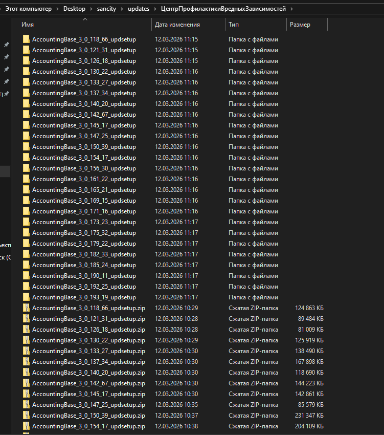

Для работы программы просто нужно выбрать базу:

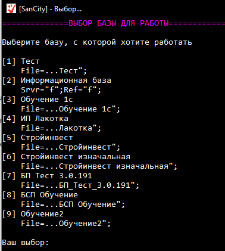

А после - ввести учетные данные, создать папку с обновлениями, выбрать, нужно ли блокировать базу, открыть сайт для загрузки обновлений и продолжить выполнение программы.

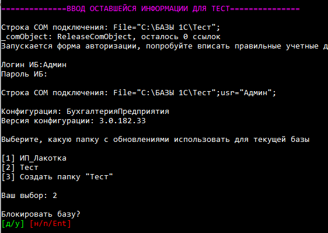

С комментария *// НАЧАЛО РЕАЛЬНОЙ РАБОТЫ* видно, что программа вообще делает - сжимает базу для ускорения процесса обновления, выгружает базу в найденный на ПК архив ИБ, устанавливает платформу, обновляет конфигурацию и так далее.

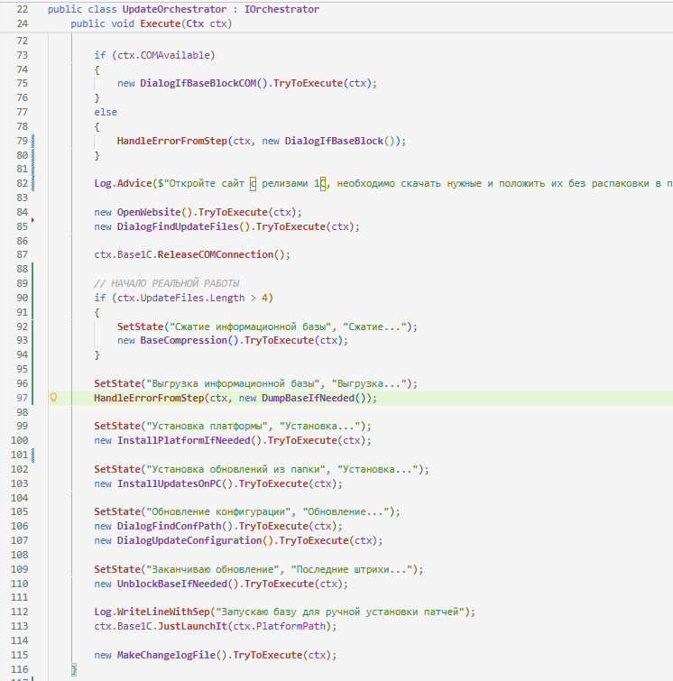

Кроме того, в программе есть и не только функционал обновления, в ней есть возможность установить обработку облачного архива в конкретную базу. И прочие параметры необходимые для автоматизации починки периодически ломающихся баз у клиентов.

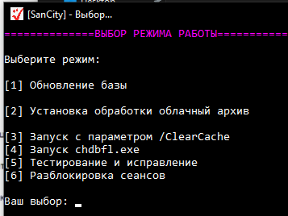

### Sancity Backuper

Sancity Backuper - решение c графическим интерфейсом для архивации ИБ. Оно в отличие от Updater уже направлено на использование клиентами.

**Функциональные возможности:**

- Выгрузка файловых и в теории - серверных ИБ.
- Выгрузка ИБ с помощью службы в системе по расписанию, которое легко задается через интерфейс программы.

**Отличие от сервиса облачный архив**

- В теории работает для серверных баз
- Удобнее для клиентов - расписание архиваций настраивается через отдельную программу, а не через обработку, которую клиент может и забыть, где найти, в ИБ.

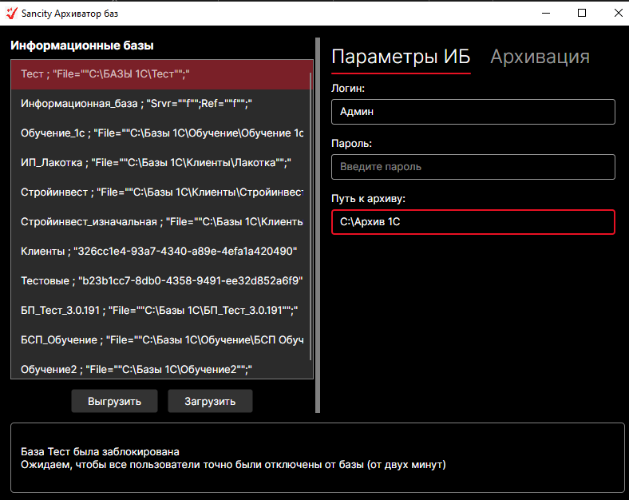

[figure not shown]